# Assignment 4

In this assignment, you'll combine the assignment 3 data set with nutrition data from the [USDA Food Composition Databases](https://ndb.nal.usda.gov/ndb/search/list). The CSV file `fresh.csv` contains the fresh fruits and vegetables data you extracted in assignment 3.

The USDA Food Composition Databases have a [documented](https://ndb.nal.usda.gov/ndb/doc/index) web API that returns data in JSON format . You need a key in order to use the API. Only 1000 requests are allowed per hour, so it would be a good idea to use [caching](https://pypi.python.org/pypi/requests-cache).

[Sign up for an API key here](https://api.data.gov/signup/). The key will work with any Data.gov API. You may need the key again later in the quarter, so make sure you save it.

These modules may be useful:

- [requests](http://docs.python-requests.org/en/master/user/quickstart/)
- [requests_cache](https://pypi.python.org/pypi/requests-cache)
- [urlparse](https://docs.python.org/2/library/urlparse.html)
- [pandas](http://pandas.pydata.org/pandas-docs/stable/)

```python
import pandas as pd
fresh = pd.read_csv("fresh.csv")
fresh
```

|  | form | price_per_lb | yield | lb_per_cup | price_per_cup | food | type |
| --- | --- | --- | --- | --- | --- | --- | --- |
| 0 | Fresh1 | 0.333412 | 0.520000 | 0.330693 | 0.212033 | watermelon | fruit |
| 1 | Fresh1 | 0.535874 | 0.510000 | 0.374786 | 0.393800 | cantaloupe | fruit |
| 2 | Fresh1 | 1.377962 | 0.740000 | 0.407855 | 0.759471 | tangerines | fruit |
| 3 | Fresh1 | 2.358808 | 0.940000 | 0.319670 | 0.802171 | strawberries | fruit |
| 4 | Fresh1 | 1.827416 | 0.940000 | 0.363763 | 0.707176 | plums | fruit |
| 5 | Fresh1 | 1.035173 | 0.730000 | 0.407855 | 0.578357 | oranges | fruit |
| 6 | Fresh1 | 6.975811 | 0.960000 | 0.319670 | 2.322874 | raspberries | fruit |
| 7 | Fresh1 | 2.173590 | 0.560000 | 0.341717 | 1.326342 | pomegranate | fruit |
| 8 | Fresh1 | 0.627662 | 0.510000 | 0.363763 | 0.447686 | pineapple | fruit |
| 9 | Fresh1 | 3.040072 | 0.930000 | 0.363763 | 1.189102 | apricots | fruit |
| 10 | Fresh1 | 0.796656 | 0.460000 | 0.374786 | 0.649077 | honeydew | fruit |
| 11 | Fresh1 | 1.298012 | 0.620000 | 0.308647 | 0.646174 | papaya | fruit |
| 12 | Fresh1 | 2.044683 | 0.760000 | 0.385809 | 1.037970 | kiwi | fruit |
| 13 | Fresh1 | 3.592990 | 0.920000 | 0.341717 | 1.334548 | cherries | fruit |
| 14 | Fresh1 | 0.566983 | 0.640000 | 0.330693 | 0.292965 | bananas | fruit |
| 15 | Fresh1 | 1.567515 | 0.900000 | 0.242508 | 0.422373 | apples | fruit |
| 16 | Fresh1 | 1.591187 | 0.960000 | 0.341717 | 0.566390 | peaches | fruit |
| 17 | Fresh1 | 1.761148 | 0.910000 | 0.319670 | 0.618667 | nectarines | fruit |
| 18 | Fresh1 | 1.461575 | 0.900000 | 0.363763 | 0.590740 | pears | fruit |
| 19 | Fresh1 | 0.897802 | 0.490000 | 0.462971 | 0.848278 | grapefruit | fruit |
| 20 | Fresh1 | 5.774708 | 0.960000 | 0.319670 | 1.922919 | blackberries | fruit |
| 21 | Fresh1 | 2.093827 | 0.960000 | 0.330693 | 0.721266 | grapes | fruit |
| 22 | Fresh1 | 4.734622 | 0.950000 | 0.319670 | 1.593177 | blueberries | fruit |
| 23 | Fresh1 | 1.377563 | 0.710000 | 0.363763 | 0.705783 | mangoes | fruit |
| 24 | Fresh1 | 3.213494 | 0.493835 | 0.396832 | 2.582272 | asparagus | vegetables |
| 25 | Fresh, consumed with peel1 | 1.295931 | 0.970000 | 0.264555 | 0.353448 | cucumbers | vegetables |
| 26 | Fresh, peeled1 | 1.295931 | 0.730000 | 0.264555 | 0.469650 | cucumbers | vegetables |
| 27 | Fresh1 | 1.213039 | 0.950000 | 0.242508 | 0.309655 | lettuce_iceberg | vegetables |
| 28 | Fresh1 | 1.038107 | 0.900000 | 0.352740 | 0.406868 | onions | vegetables |
| 29 | Fresh1 | 2.471749 | 0.750000 | 0.319670 | 1.053526 | turnip_greens | vegetables |
| 30 | Fresh1 | 2.569235 | 0.840000 | 0.308647 | 0.944032 | mustard_greens | vegetables |
| 31 | Fresh1 | 0.564320 | 0.811301 | 0.264555 | 0.184017 | potatoes | vegetables |
| 32 | Fresh1 | 2.630838 | 1.160000 | 0.286601 | 0.650001 | collard_greens | vegetables |
| 33 | Fresh1 | 2.139972 | 0.846575 | 0.275578 | 0.696606 | green_beans | vegetables |
| 34 | Fresh1 | 1.172248 | 0.458554 | 0.451948 | 1.155360 | acorn_squash | vegetables |
| 35 | Fresh1 | 2.277940 | 0.820000 | 0.264555 | 0.734926 | red_peppers | vegetables |
| 36 | Fresh green cabbage1 | 0.579208 | 0.778797 | 0.330693 | 0.245944 | cabbage | vegetables |
| 37 | Fresh red cabbage1 | 1.056450 | 0.779107 | 0.330693 | 0.448412 | cabbage | vegetables |
| 38 | Fresh1 | 0.918897 | 0.811301 | 0.440925 | 0.499400 | sweet_potatoes | vegetables |
| 39 | Fresh1 | 1.639477 | 0.769500 | 0.396832 | 0.845480 | summer_squash | vegetables |
| 40 | Fresh1 | 1.311629 | 0.900000 | 0.275578 | 0.401618 | radish | vegetables |
| 41 | Fresh1 | 1.244737 | 0.714000 | 0.451948 | 0.787893 | butternut_squash | vegetables |
| 42 | Fresh1 | 2.235874 | 0.740753 | 0.319670 | 0.964886 | avocados | vegetables |
| 43 | Fresh1 | 2.807302 | 1.050000 | 0.286601 | 0.766262 | kale | vegetables |
| 44 | Fresh1 | 2.213050 | 0.375309 | 0.385809 | 2.274967 | artichoke | vegetables |
| 45 | Fresh1 | 3.213552 | 0.769474 | 0.352740 | 1.473146 | okra | vegetables |
| 46 | Fresh1 | 1.410363 | 0.820000 | 0.264555 | 0.455022 | green_peppers | vegetables |
| 47 | Fresh1 | 2.763553 | 1.060000 | 0.341717 | 0.890898 | brussels_sprouts | vegetables |
| 48 | Fresh1 | 2.690623 | 0.540000 | 0.363763 | 1.812497 | corn_sweet | vegetables |

```python
fresh.loc[fresh.form == 'Fresh red cabbage1', 'food'] = 'cabbage_red'
fresh.loc[fresh.form == 'Fresh, consumed with peel1', 'food'] = 'cucumber_with_peel'
fresh.loc[fresh.form == 'Fresh, peeled1', 'food'] = 'cucumber_peeled'
```

```python
fresh
```

|  | form | price_per_lb | yield | lb_per_cup | price_per_cup | food | type |
| --- | --- | --- | --- | --- | --- | --- | --- |
| 0 | Fresh1 | 0.333412 | 0.520000 | 0.330693 | 0.212033 | watermelon | fruit |
| 1 | Fresh1 | 0.535874 | 0.510000 | 0.374786 | 0.393800 | cantaloupe | fruit |
| 2 | Fresh1 | 1.377962 | 0.740000 | 0.407855 | 0.759471 | tangerines | fruit |
| 3 | Fresh1 | 2.358808 | 0.940000 | 0.319670 | 0.802171 | strawberries | fruit |
| 4 | Fresh1 | 1.827416 | 0.940000 | 0.363763 | 0.707176 | plums | fruit |
| 5 | Fresh1 | 1.035173 | 0.730000 | 0.407855 | 0.578357 | oranges | fruit |
| 6 | Fresh1 | 6.975811 | 0.960000 | 0.319670 | 2.322874 | raspberries | fruit |
| 7 | Fresh1 | 2.173590 | 0.560000 | 0.341717 | 1.326342 | pomegranate | fruit |
| 8 | Fresh1 | 0.627662 | 0.510000 | 0.363763 | 0.447686 | pineapple | fruit |
| 9 | Fresh1 | 3.040072 | 0.930000 | 0.363763 | 1.189102 | apricots | fruit |
| 10 | Fresh1 | 0.796656 | 0.460000 | 0.374786 | 0.649077 | honeydew | fruit |
| 11 | Fresh1 | 1.298012 | 0.620000 | 0.308647 | 0.646174 | papaya | fruit |
| 12 | Fresh1 | 2.044683 | 0.760000 | 0.385809 | 1.037970 | kiwi | fruit |
| 13 | Fresh1 | 3.592990 | 0.920000 | 0.341717 | 1.334548 | cherries | fruit |
| 14 | Fresh1 | 0.566983 | 0.640000 | 0.330693 | 0.292965 | bananas | fruit |
| 15 | Fresh1 | 1.567515 | 0.900000 | 0.242508 | 0.422373 | apples | fruit |
| 16 | Fresh1 | 1.591187 | 0.960000 | 0.341717 | 0.566390 | peaches | fruit |
| 17 | Fresh1 | 1.761148 | 0.910000 | 0.319670 | 0.618667 | nectarines | fruit |
| 18 | Fresh1 | 1.461575 | 0.900000 | 0.363763 | 0.590740 | pears | fruit |
| 19 | Fresh1 | 0.897802 | 0.490000 | 0.462971 | 0.848278 | grapefruit | fruit |
| 20 | Fresh1 | 5.774708 | 0.960000 | 0.319670 | 1.922919 | blackberries | fruit |
| 21 | Fresh1 | 2.093827 | 0.960000 | 0.330693 | 0.721266 | grapes | fruit |
| 22 | Fresh1 | 4.734622 | 0.950000 | 0.319670 | 1.593177 | blueberries | fruit |
| 23 | Fresh1 | 1.377563 | 0.710000 | 0.363763 | 0.705783 | mangoes | fruit |
| 24 | Fresh1 | 3.213494 | 0.493835 | 0.396832 | 2.582272 | asparagus | vegetables |
| 25 | Fresh, consumed with peel1 | 1.295931 | 0.970000 | 0.264555 | 0.353448 | cucumber_with_peel | vegetables |
| 26 | Fresh, peeled1 | 1.295931 | 0.730000 | 0.264555 | 0.469650 | cucumber_peeled | vegetables |
| 27 | Fresh1 | 1.213039 | 0.950000 | 0.242508 | 0.309655 | lettuce_iceberg | vegetables |
| 28 | Fresh1 | 1.038107 | 0.900000 | 0.352740 | 0.406868 | onions | vegetables |
| 29 | Fresh1 | 2.471749 | 0.750000 | 0.319670 | 1.053526 | turnip_greens | vegetables |
| 30 | Fresh1 | 2.569235 | 0.840000 | 0.308647 | 0.944032 | mustard_greens | vegetables |
| 31 | Fresh1 | 0.564320 | 0.811301 | 0.264555 | 0.184017 | potatoes | vegetables |
| 32 | Fresh1 | 2.630838 | 1.160000 | 0.286601 | 0.650001 | collard_greens | vegetables |
| 33 | Fresh1 | 2.139972 | 0.846575 | 0.275578 | 0.696606 | green_beans | vegetables |
| 34 | Fresh1 | 1.172248 | 0.458554 | 0.451948 | 1.155360 | acorn_squash | vegetables |
| 35 | Fresh1 | 2.277940 | 0.820000 | 0.264555 | 0.734926 | red_peppers | vegetables |
| 36 | Fresh green cabbage1 | 0.579208 | 0.778797 | 0.330693 | 0.245944 | cabbage | vegetables |
| 37 | Fresh red cabbage1 | 1.056450 | 0.779107 | 0.330693 | 0.448412 | cabbage_red | vegetables |
| 38 | Fresh1 | 0.918897 | 0.811301 | 0.440925 | 0.499400 | sweet_potatoes | vegetables |
| 39 | Fresh1 | 1.639477 | 0.769500 | 0.396832 | 0.845480 | summer_squash | vegetables |
| 40 | Fresh1 | 1.311629 | 0.900000 | 0.275578 | 0.401618 | radish | vegetables |
| 41 | Fresh1 | 1.244737 | 0.714000 | 0.451948 | 0.787893 | butternut_squash | vegetables |
| 42 | Fresh1 | 2.235874 | 0.740753 | 0.319670 | 0.964886 | avocados | vegetables |
| 43 | Fresh1 | 2.807302 | 1.050000 | 0.286601 | 0.766262 | kale | vegetables |
| 44 | Fresh1 | 2.213050 | 0.375309 | 0.385809 | 2.274967 | artichoke | vegetables |
| 45 | Fresh1 | 3.213552 | 0.769474 | 0.352740 | 1.473146 | okra | vegetables |
| 46 | Fresh1 | 1.410363 | 0.820000 | 0.264555 | 0.455022 | green_peppers | vegetables |
| 47 | Fresh1 | 2.763553 | 1.060000 | 0.341717 | 0.890898 | brussels_sprouts | vegetables |
| 48 | Fresh1 | 2.690623 | 0.540000 | 0.363763 | 1.812497 | corn_sweet | vegetables |

**Exercise 1.1.** Read the [search request documentation](https://ndb.nal.usda.gov/ndb/doc/apilist/API-SEARCH.md), then write a function called `ndb_search()` that makes a search request. The function should accept the search term as an argument. The function should return the search result items as a list (for 0 items, return an empty list).

Note that the search url is: `https://api.nal.usda.gov/ndb/search`

As an example, a search for `"quail eggs"` should return this list:

```
[{u'ds': u'BL',
  u'group': u'Branded Food Products Database',
  u'name': u'CHAOKOH, QUAIL EGG IN BRINE, UPC: 044738074186',
  u'ndbno': u'45094707',
  u'offset': 0},
 {u'ds': u'BL',
  u'group': u'Branded Food Products Database',
  u'name': u'L&W, QUAIL EGGS, UPC: 024072000256',
  u'ndbno': u'45094890',
  u'offset': 1},
 {u'ds': u'BL',
  u'group': u'Branded Food Products Database',
  u'name': u'BUDDHA, QUAIL EGGS IN BRINE, UPC: 761934535098',
  u'ndbno': u'45099560',
  u'offset': 2},
 {u'ds': u'BL',
  u'group': u'Branded Food Products Database',
  u'name': u'GRAN SABANA, QUAIL EGGS, UPC: 819140010103',
  u'ndbno': u'45169279',
  u'offset': 3},
 {u'ds': u'BL',
  u'group': u'Branded Food Products Database',
  u'name': u"D'ARTAGNAN, QUAIL EGGS, UPC: 736622102630",
  u'ndbno': u'45178254',
  u'offset': 4},
 {u'ds': u'SR',
  u'group': u'Dairy and Egg Products',
  u'name': u'Egg, quail, whole, fresh, raw',
  u'ndbno': u'01140',
  u'offset': 5}]
```

As usual, make sure you document and test your function.

```python
from urllib2 import Request, urlopen
import json
# Gets search URL and gets request function
def ndb_search(key, search):
    search = list(search)
    for i in range (0, len(search)):
        if search[i] == ' ':
            search[i] = '_'
    search = "".join(search)
    search = str(search)
    searchurl = 'https://api.nal.usda.gov/ndb/search?format=json&q=' + search + '&sort=n&max=25&offset=0&api_key=' + key
    request = Request(searchurl)
    response = urlopen(request)
    rr = response.read()
    js = json.loads(rr)
    return js[u'list']
```

```python
results = ndb_search('A8tjHzrA9pJQTudS94B6XSGMB3BzXeSSwrgUGlix', 'quail eggs')
```

```python
results
```

```
{u'ds': u'any',
 u'end': 5,
 u'group': u'',
 u'item': [{u'ds': u'BL',
   u'group': u'Branded Food Products Database',
   u'name': u'BUDDHA, QUAIL EGGS IN BRINE, UPC: 761934535098',
   u'ndbno': u'45099560',
   u'offset': 0},
  {u'ds': u'BL',
   u'group': u'Branded Food Products Database',
   u'name': u'CHAOKOH, QUAIL EGG IN BRINE, UPC: 044738074186',
   u'ndbno': u'45094707',
   u'offset': 1},
  {u'ds': u'BL',
   u'group': u'Branded Food Products Database',
   u'name': u"D'ARTAGNAN, QUAIL EGGS, UPC: 736622102630",
   u'ndbno': u'45178254',
   u'offset': 2},
  {u'ds': u'BL',
   u'group': u'Branded Food Products Database',
   u'name': u'GRAN SABANA, QUAIL EGGS, UPC: 819140010103',
   u'ndbno': u'45169279',
   u'offset': 3},
  {u'ds': u'BL',
   u'group': u'Branded Food Products Database',
   u'name': u'L&W, QUAIL EGGS, UPC: 024072000256',
   u'ndbno': u'45094890',
   u'offset': 4}],
 u'q': u'quail_eggs',
 u'sort': u'n',
 u'sr': u'28',
 u'start': 0,
 u'total': 5}
```

**Exercise 1.2.** Use your search function to get NDB numbers for the foods in the `fresh.csv` file. It's okay if you don't get an NDB number for every food, but try to come up with a strategy that gets most of them. Discuss your strategy in a short paragraph.

Hints:

- The foods are all raw and unbranded.
- You can test search terms with the [online search page](https://ndb.nal.usda.gov/ndb/search/list).
- You can convert the output of `ndb_search()` to a data frame with `pd.DataFrame()`.
- The string methods for [Python](https://docs.python.org/2/library/stdtypes.html#string-methods) and [Pandas](http://pandas.pydata.org/pandas-docs/stable/text.html#method-summary) are useful here. It's okay if you use *simple* regular expressions in the Pandas methods, although this exercise can be solved without them.
- You can merge data frames that have a column in common with `pd.merge()`.

```python
# Get list of foods and appends raw next the them
foods = (fresh[['food']])
len(foods.index)
foodlist = []
for i in range(0, len(foods.index)):
    foodlist.append(foods.iloc[i]['food'])
    foodlist[i] = foodlist[i] + ' raw'
foodlist[0:4]
```

```
['watermelon raw', 'cantaloupe raw', 'tangerines raw', 'strawberries raw']
```

```python
# Gets list of observations
observations = []
for i in range(0, len(foodlist)):
    try:
        observations.append(ndb_search('A8tjHzrA9pJQTudS94B6XSGMB3BzXeSSwrgUGlix', foodlist[i]))
    except KeyError:
        continue
```

```python
numbers = pd.DataFrame(observations)
```

```python
numbers.head()
```

|  | ds | end | group | item | q | sort | sr | start | total |
| --- | --- | --- | --- | --- | --- | --- | --- | --- | --- |
| 0 | any | 1 |  | [{u'ndbno': u'09326', u'group': u'Fruits and F... | watermelon_raw | n | 28 | 0 | 1 |
| 1 | any | 1 |  | [{u'ndbno': u'09181', u'group': u'Fruits and F... | cantaloupe_raw | n | 28 | 0 | 1 |
| 2 | any | 2 |  | [{u'ndbno': u'09140', u'group': u'Fruits and F... | strawberries_raw | n | 28 | 0 | 2 |
| 3 | any | 2 |  | [{u'ndbno': u'09061', u'group': u'Fruits and F... | plums_raw | n | 28 | 0 | 2 |
| 4 | any | 8 |  | [{u'ndbno': u'15073', u'group': u'Finfish and ... | oranges_raw | n | 28 | 0 | 8 |

```python
# Delete raw and make new dataframe
freshfood = (numbers[['q']])
len(freshfood.index)
freshlist = []
for i in range(0, len(freshfood.index)):
    freshlist.append(str(freshfood.iloc[i]['q']))
    freshlist[i] = freshlist[i].rstrip('_raw')
freshlist[0:4]
```

```
['watermelon', 'cantaloupe', 'strawberries', 'plums']
```

```python
# Get numbers in dataframe
num = (numbers[['item']])
len(freshfood.index)
# The [14:19] of the string returns the number for each observation so I get that into a list
str(num.iloc[0]['item'])[14:19]
numlist = []
for i in range(0, len(num.index)):
    numlist.append(str(num.iloc[i]['item'])[14:19])
numlist[0:4]
```

```
['09326', '09181', '09140', '09061']
```

```python
# Make new dataframe with only the numbers and foods
numdf = pd.DataFrame({'food': freshlist, 'number': numlist}, index = range(0, len(numlist)))
numdf.head()
```

|  | food | number |
| --- | --- | --- |
| 0 | watermelon | 09326 |
| 1 | cantaloupe | 09181 |
| 2 | strawberries | 09140 |
| 3 | plums | 09061 |
| 4 | oranges | 15073 |

```python
# Merge the two dataframes together
newdf = pd.merge(fresh, numdf, on = 'food')
newdf.head()
```

|  | form | price_per_lb | yield | lb_per_cup | price_per_cup | food | type | number |
| --- | --- | --- | --- | --- | --- | --- | --- | --- |
| 0 | Fresh1 | 0.333412 | 0.52 | 0.330693 | 0.212033 | watermelon | fruit | 09326 |
| 1 | Fresh1 | 0.535874 | 0.51 | 0.374786 | 0.393800 | cantaloupe | fruit | 09181 |
| 2 | Fresh1 | 2.358808 | 0.94 | 0.319670 | 0.802171 | strawberries | fruit | 09140 |
| 3 | Fresh1 | 1.827416 | 0.94 | 0.363763 | 0.707176 | plums | fruit | 09061 |
| 4 | Fresh1 | 1.035173 | 0.73 | 0.407855 | 0.578357 | oranges | fruit | 15073 |

For this exercise, I first extracted the foods from the fresh dataframe and appended the string ' raw' to them so that I could use them for my search. I searched through the whole list of values and got the item object which contains the number in them in a new data frame. I extracted the numbers and foods and stripped the raw from them back so that I can make a new dataframe with only the foods and numbers. Then I merged the two dataframes together using the food as my key. I also converted some of the duplicate foods such as cucumbers and cabbage to their specific names to make this more accurate.

**Exercise 1.3.** Read the [food reports V2 documentation](https://ndb.nal.usda.gov/ndb/doc/apilist/API-FOOD-REPORTV2.md), then write a function called `ndb_report()` that requests a *basic* food report. The function should accept the NDB number as an argument and return the list of nutrients for the food.

Note that the report url is: `https://api.nal.usda.gov/ndb/V2/reports`

For example, for `"09279"` (raw plums) the first element of the returned list should be:

```
{u'group': u'Proximates',
 u'measures': [{u'eqv': 165.0,
   u'eunit': u'g',
   u'label': u'cup, sliced',
   u'qty': 1.0,
   u'value': u'143.93'},
  {u'eqv': 66.0,
   u'eunit': u'g',
   u'label': u'fruit (2-1/8" dia)',
   u'qty': 1.0,
   u'value': u'57.57'},
  {u'eqv': 151.0,
   u'eunit': u'g',
   u'label': u'NLEA serving',
   u'qty': 1.0,
   u'value': u'131.72'}],
 u'name': u'Water',
 u'nutrient_id': u'255',
 u'unit': u'g',
 u'value': u'87.23'}
```

Be sure to document and test your function.

```python
# Gets search URL and gets request function
def ndb_report(key, search):
    searchurl = 'https://api.nal.usda.gov/ndb/V2/reports?ndbno=' + search + '&type=f&format=json&api_key=' + key
    request = Request(searchurl)
    response = urlopen(request)
    rr = response.read()
    js = json.loads(rr)
    return js[u'foods'][0][u'food'][u'nutrients'][0]
```

```python
report = ndb_report('A8tjHzrA9pJQTudS94B6XSGMB3BzXeSSwrgUGlix', '09279')
```

```python
report
```

```
{u'dp': 10,
 u'group': u'Proximates',
 u'measures': [{u'eqv': 165.0,
   u'eunit': u'g',
   u'label': u'cup, sliced',
   u'qty': 1.0,
   u'value': 143.93},
  {u'eqv': 66.0,
   u'eunit': u'g',
   u'label': u'fruit (2-1/8" dia)',
   u'qty': 1.0,
   u'value': 57.57},
  {u'eqv': 151.0,
   u'eunit': u'g',
   u'label': u'NLEA serving',
   u'qty': 1.0,
   u'value': 131.72}],
 u'name': u'Water',
 u'nutrient_id': 255,
 u'se': u'0.328',
 u'sourcecode': [1, 2, 3],
 u'unit': u'g',
 u'value': 87.23}
```

**Exercise 1.4.** Which foods provide the best combination of price, yield, and nutrition? You can use kilocalories as a measure of "nutrition" here, but more a detailed analysis is better. Use plots to support your analysis.

```python
# Gets nutrients
nutrients = []
for i in range(0, len(newdf.index)):
    try:
        nutrients.append(ndb_report('A8tjHzrA9pJQTudS94B6XSGMB3BzXeSSwrgUGlix', newdf.iloc[i]['number']))
    except KeyError:
        continue
```

```python
nutrients
```

[output not shown]

[output cut: 839 more lines]

[output not shown]

```python
nutdf = pd.DataFrame(nutrients)
```

```python
nutdf.head()
```

|  | dp | group | measures | name | nutrient_id | se | sourcecode | unit | value |
| --- | --- | --- | --- | --- | --- | --- | --- | --- | --- |
| 0 | 14 | Proximates | [{u'eunit': u'g', u'eqv': 154.0, u'qty': 1.0, ... | Water | 255 | 0.316 | [1, 2, 3, 4, 5, 6] | g | 91.45 |
| 1 | 30 | Proximates | [{u'eunit': u'g', u'eqv': 177.0, u'qty': 1.0, ... | Water | 255 | 0.312 | [1, 2, 3, 4, 5, 6, 7] | g | 90.15 |
| 2 | 2 | Proximates | [{u'eunit': u'g', u'eqv': 244.0, u'qty': 1.0, ... | Water | 255 |  |  | g | 80.66 |
| 3 | 1 | Proximates | [{u'eunit': u'g', u'eqv': 150.0, u'qty': 1.0, ... | Water | 255 |  |  | g | 84.17 |
| 4 | 3 | Proximates | [{u'eunit': u'g', u'eqv': 85.0, u'qty': 3.0, u... | Water | 255 | 1.352 | [1] | g | 75.67 |

```python
# Get water values in dataframe
nutvalue = (nutdf[['value']])
nutvalue.head()
```

|  | value |
| --- | --- |
| 0 | 91.45 |
| 1 | 90.15 |
| 2 | 80.66 |
| 3 | 84.17 |
| 4 | 75.67 |

```python
# Since I ran the basic report function from the foods I originally got, the each value should correspond with the correct food
newdf = newdf.join(nutvalue)
```

```python
newdf.head()
```

|  | form | price_per_lb | yield | lb_per_cup | price_per_cup | food | type | number | value |
| --- | --- | --- | --- | --- | --- | --- | --- | --- | --- |
| 0 | Fresh1 | 0.333412 | 0.52 | 0.330693 | 0.212033 | watermelon | fruit | 09326 | 91.45 |
| 1 | Fresh1 | 0.535874 | 0.51 | 0.374786 | 0.393800 | cantaloupe | fruit | 09181 | 90.15 |
| 2 | Fresh1 | 2.358808 | 0.94 | 0.319670 | 0.802171 | strawberries | fruit | 09140 | 80.66 |
| 3 | Fresh1 | 1.827416 | 0.94 | 0.363763 | 0.707176 | plums | fruit | 09061 | 84.17 |
| 4 | Fresh1 | 1.035173 | 0.73 | 0.407855 | 0.578357 | oranges | fruit | 15073 | 75.67 |

```python
price_per_lb = newdf[['price_per_lb']]
price_per_lb.head()
```

|  | price_per_lb |
| --- | --- |
| 0 | 0.333412 |
| 1 | 0.535874 |
| 2 | 2.358808 |
| 3 | 1.827416 |
| 4 | 1.035173 |

```python
yields = newdf[['yield']]
yields.head()
```

|  | yield |
| --- | --- |
| 0 | 0.52 |
| 1 | 0.51 |
| 2 | 0.94 |
| 3 | 0.94 |
| 4 | 0.73 |

```python
water = newdf[['value']]
water.head()
```

|  | value |
| --- | --- |
| 0 | 91.45 |
| 1 | 90.15 |
| 2 | 80.66 |
| 3 | 84.17 |
| 4 | 75.67 |

```python
from matplotlib import pyplot as plt
plt.style.use('ggplot')
```

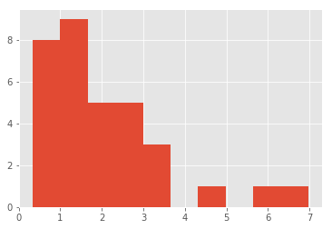

```python
plt.hist(price_per_lb['price_per_lb'], label = "Price")
plt.show()
```

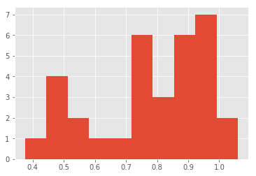

```python
plt.hist(yields['yield'], label = "Yield")
plt.show()
```

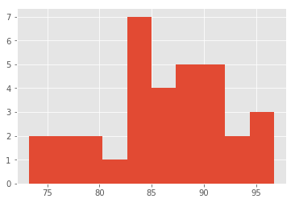

```python
plt.hist(water['value'], label = "Water Value")
plt.show()
```

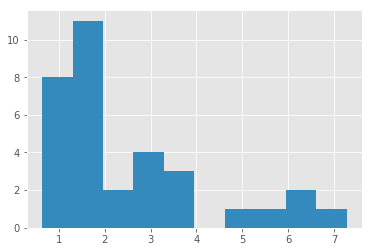

```python
ratio = price_per_lb['price_per_lb']/yields['yield']
newdf['ratio'] = ratio
ratio = newdf[['ratio']]
plt.hist(ratio['ratio'], label = "Price and Yield Ratio")
plt.show()
```

```python
cheapfoods = newdf.loc[newdf['price_per_lb'] < 1]
highyields = newdf.loc[newdf['yield'] > 0.9]
highratio = newdf.loc[newdf['ratio'] > 5]
highwater = newdf.loc[newdf['value'] > 90]
print cheapfoods.iloc[0:len(cheapfoods.index)]['food']
print highyields.iloc[0:len(highyields.index)]['food']
print highwater.iloc[0:len(highwater.index)]['food']
print highratio.iloc[0:len(highratio.index)]['food']
```

```
0         watermelon
1         cantaloupe
7          pineapple
10           bananas
14        grapefruit
24          potatoes
25           cabbage
27    sweet_potatoes
Name: food, dtype: object
2           strawberries
3                  plums
5            raspberries
8               apricots
9               cherries
12            nectarines
```

[output cut: 22 more lines]